# COM736 Coursework 2 – AIBL Data Validation and Visualisation

Emmanuel Bajimi | B00997887 |

2026-05-05

# 1 Step 1 – Problem Statement

The Australian Imaging Biomarkers and Lifestyle (AIBL) study collected clinical, demographic, blood-biomarker, and cognitive data from 862 participants at baseline. Each participant was clinically classified as either a **Healthy Control (HC)**, someone with **Mild Cognitive Impairment (MCI)**, or someone with **Alzheimer’s Disease (AD)**. This study re-frames the three-class problem as a binary one: **HC vs Non-HC** (combining MCI and AD as a single adverse outcome class).

The goal is to build the most **economical** machine-learning diagnostic pipeline — one that accurately separates HC from Non-HC using the **fewest possible tests**, favouring low-cost, non-invasive assessments (cognitive and demographic) over expensive blood or genomic assays. Recursive Feature Elimination (RFE) is used to objectively identify the minimal optimal feature subset, removing the subjectivity of manual configuration selection.

# 2 Step 2 – Data Identification and Loading

The AIBL dataset is organised across 8 CSV files, each identified by a common participant key (`RID`). Data collection was cross-sectional at baseline (visit code `bl`). The files cover: patient demographics, medical history, ApoE genotype, blood-based laboratory values, clinical dementia rating (CDR), mini-mental state exam (MMSE), neuropsychological battery scores, and clinical diagnosis.

```r
required_pkgs <- c(
  "tidyverse", "caret", "randomForest", "e1071",
  "corrplot", "ggplot2", "pROC", "knitr", "kableExtra",
  "gridExtra", "scales", "RColorBrewer", "factoextra",
  "skimr", "ROSE", "glmnet", "rpart", "rpart.plot",
  "GGally", "ggcorrplot", "VIM", "mice", "kernlab",
  "gbm", "doParallel", "klaR"
)
new_pkgs <- required_pkgs[!required_pkgs %in% installed.packages()[,"Package"]]
if (length(new_pkgs)) install.packages(new_pkgs, repos = "https://cloud.r-project.org")

library(tidyverse)
library(caret)
library(randomForest)
library(e1071)
library(corrplot)
library(ggplot2)
library(pROC)
library(knitr)
library(kableExtra)
library(gridExtra)
library(scales)
library(RColorBrewer)
library(factoextra)
library(skimr)
library(ROSE)
library(glmnet)
library(rpart)
library(rpart.plot)
library(GGally)
library(ggcorrplot)
library(VIM)
library(mice)
library(kernlab)
library(gbm)
library(doParallel)
```

```r
DATA_DIR <- "dataset"

ptdemog  <- read_csv(file.path(DATA_DIR, "aibl_ptdemog_01-Jun-2018.csv"),
                     show_col_types = FALSE)
medhist  <- read_csv(file.path(DATA_DIR, "aibl_medhist_01-Jun-2018.csv"),
                     show_col_types = FALSE)
apoeres  <- read_csv(file.path(DATA_DIR, "aibl_apoeres_01-Jun-2018.csv"),
                     show_col_types = FALSE)
labdata  <- read_csv(file.path(DATA_DIR, "aibl_labdata_01-Jun-2018.csv"),
                     show_col_types = FALSE)
cdr      <- read_csv(file.path(DATA_DIR, "aibl_cdr_01-Jun-2018.csv"),
                     show_col_types = FALSE)
mmse     <- read_csv(file.path(DATA_DIR, "aibl_mmse_01-Jun-2018.csv"),
                     show_col_types = FALSE)
neurobat <- read_csv(file.path(DATA_DIR, "aibl_neurobat_01-Jun-2018.csv"),
                     show_col_types = FALSE)
pdxconv  <- read_csv(file.path(DATA_DIR, "aibl_pdxconv_01-Jun-2018.csv"),
                     show_col_types = FALSE)

cat("Files loaded successfully.\n")
```

```
## Files loaded successfully.
```

```r
cat("Row counts per file (before baseline filter):\n")
```

```
## Row counts per file (before baseline filter):
```

```r
lapply(list(ptdemog=ptdemog, medhist=medhist, apoeres=apoeres,
            labdata=labdata, cdr=cdr, mmse=mmse,
            neurobat=neurobat, pdxconv=pdxconv), nrow) %>%
  as.data.frame() %>% t() %>%
  kable(col.names = "Rows", caption = "Raw row counts per source file") %>%
  kable_styling(bootstrap_options = "striped")
```

Raw row counts per source file

|  | Rows |
| --- | --- |
| ptdemog | 862 |
| medhist | 862 |
| apoeres | 862 |
| labdata | 1688 |
| cdr | 1688 |
| mmse | 1688 |
| neurobat | 1688 |
| pdxconv | 1688 |

```r
# Retain baseline visits only (VISCODE == "bl")
bl_filter <- function(df) filter(df, str_trim(VISCODE) == "bl")

ptdemog  <- bl_filter(ptdemog)
medhist  <- bl_filter(medhist)
apoeres  <- bl_filter(apoeres)
labdata  <- bl_filter(labdata)
cdr      <- bl_filter(cdr)
mmse     <- bl_filter(mmse)
neurobat <- bl_filter(neurobat)
pdxconv  <- bl_filter(pdxconv)

cat(sprintf("Baseline participants retained: %d\n", nrow(pdxconv)))
```

```
## Baseline participants retained: 862
```

# 3 Step 3 – Data Merging, Inspection, and Cleaning

## 3.1 3.1 Feature Engineering Before Merge

```r
# Demographics: derive AGE from date of birth; encode gender as factor
ptdemog <- ptdemog %>%
  mutate(
    birth_year = as.numeric(str_extract(PTDOB, "\\d{4}")),
    AGE        = 2007 - birth_year,
    PTGENDER   = factor(PTGENDER, levels = c(1, 2),
                        labels = c("Male", "Female"))
  ) %>%
  select(RID, AGE, PTGENDER)

# Medical history: recode -4 (unknown/not assessed) as NA
mh_cols <- c("MHPSYCH","MH2NEURL","MH4CARD","MH6HEPAT",
             "MH8MUSCL","MH9ENDO","MH10GAST","MH12RENA","MH16SMOK","MH17MALI")
medhist <- medhist %>%
  mutate(across(all_of(mh_cols), ~ if_else(. == -4, NA_real_, as.double(.)))) %>%
  select(RID, all_of(mh_cols))

# ApoE genotype: recode -4 as NA
apoeres <- apoeres %>%
  mutate(
    APGEN1 = if_else(APGEN1 == -4, NA_real_, as.double(APGEN1)),
    APGEN2 = if_else(APGEN2 == -4, NA_real_, as.double(APGEN2))
  ) %>%
  select(RID, APGEN1, APGEN2)

# Lab data: rename raw codes to readable names
labdata <- labdata %>%
  rename(
    TSH         = AXT117,
    VitB12      = BAT126,
    RBC         = HMT3,
    WBC         = HMT7,
    Platelets   = HMT13,
    Haemoglobin = HMT40,
    MCH         = HMT100,
    MCHC        = HMT102,
    BUN         = RCT6,
    Glucose     = RCT11,
    Cholesterol = RCT20,
    Creatinine  = RCT392
  ) %>%
  select(RID, TSH, VitB12, RBC, WBC, Platelets, Haemoglobin,
         MCH, MCHC, BUN, Glucose, Cholesterol, Creatinine)

cdr      <- cdr      %>% select(RID, CDR  = CDGLOBAL)
mmse     <- mmse     %>% select(RID, MMSE = MMSCORE)
neurobat <- neurobat %>% select(RID, LMIR = LIMMTOTAL, LMDR = LDELTOTAL)

# Target: binary HC vs Non-HC
pdxconv <- pdxconv %>%
  filter(DXCURREN %in% c(1, 2, 3)) %>%
  mutate(
    DXCURREN3 = factor(DXCURREN, levels = c(1,2,3),
                       labels = c("HC","MCI","AD")),
    Label     = factor(if_else(DXCURREN == 1, "HC", "NonHC"),
                       levels = c("HC","NonHC"))
  ) %>%
  select(RID, DXCURREN3, Label)

cat("Target label distribution at baseline:\n")
```

```
## Target label distribution at baseline:
```

```r
print(table(pdxconv$Label))
```

```
##
##    HC NonHC
##   609   249
```

## 3.2 3.2 Merge All Sources

```r
aibl <- pdxconv %>%
  left_join(ptdemog,  by = "RID") %>%
  left_join(medhist,  by = "RID") %>%
  left_join(apoeres,  by = "RID") %>%
  left_join(labdata,  by = "RID") %>%
  left_join(cdr,      by = "RID") %>%
  left_join(mmse,     by = "RID") %>%
  left_join(neurobat, by = "RID")

# Fix CDR sentinel value
aibl <- aibl %>%
  mutate(CDR = if_else(CDR == -4, NA_real_, CDR))

cat(sprintf("Merged dataset: %d rows × %d columns\n", nrow(aibl), ncol(aibl)))
```

```
## Merged dataset: 858 rows × 33 columns
```

```r
glimpse(aibl)
```

```
## Rows: 858
## Columns: 33
## $ RID         <dbl> 2, 3, 4, 5, 10, 11, 12, 14, 15, 16, 17, 18, 19, 20, 21, 22…
## $ DXCURREN3   <fct> HC, HC, HC, MCI, AD, HC, MCI, HC, MCI, HC, HC, HC, AD, HC,…
## $ Label       <fct> HC, HC, HC, NonHC, NonHC, HC, NonHC, HC, NonHC, HC, HC, HC…
## $ AGE         <dbl> 66, 68, 85, 74, 82, 90, 79, 66, 87, 81, 79, 64, 81, 73, 74…
## $ PTGENDER    <fct> Male, Female, Female, Male, Male, Male, Male, Female, Male…
## $ MHPSYCH     <dbl> 0, 1, 0, 0, 0, 0, 0, 1, 0, 0, 0, NA, 0, 0, 0, 0, 1, NA, 1,…
## $ MH2NEURL    <dbl> 1, 0, 0, 0, 0, 0, 0, 1, 0, 0, 0, NA, 1, 0, 0, 0, 0, NA, 0,…
## $ MH4CARD     <dbl> 0, 0, 1, 1, 0, 1, 1, 0, 1, 0, 1, NA, 0, 0, 0, 1, 0, NA, 1,…
## $ MH6HEPAT    <dbl> 0, 0, 0, 0, 0, 0, 0, 0, 0, 0, 0, NA, 0, 0, 0, 0, 0, NA, 0,…
## $ MH8MUSCL    <dbl> 0, 0, 1, 0, 0, 0, 1, 1, 1, 1, 0, NA, 1, 0, 1, 0, 1, NA, 1,…
## $ MH9ENDO     <dbl> 0, 0, 0, 1, 0, 0, 0, 0, 0, 0, 0, NA, 0, 0, 0, 0, 0, NA, 0,…
## $ MH10GAST    <dbl> 0, 1, 0, 0, 0, 1, 0, 1, 0, 1, 1, NA, 1, 0, 0, 0, 0, NA, 0,…
## $ MH12RENA    <dbl> 0, 0, 0, 0, 0, 0, 0, 0, 0, 0, 0, NA, 0, 0, 0, 0, 0, NA, 0,…
```

[output cut: 20 more lines]

## 3.3 3.3 Missing Data Analysis

```r
miss_df <- aibl %>%
  summarise(across(everything(), ~ sum(is.na(.)))) %>%
  pivot_longer(everything(), names_to = "Variable", values_to = "Missing") %>%
  filter(Missing > 0) %>%
  mutate(Pct = Missing / nrow(aibl) * 100) %>%
  arrange(desc(Pct))

kable(miss_df, digits = 1,
      caption = "Missing value summary (variables with at least one NA)") %>%
  kable_styling(bootstrap_options = c("striped","hover","condensed"))
```

Missing value summary (variables with at least one NA)

| Variable | Missing | Pct |
| --- | --- | --- |
| MH16SMOK | 311 | 36.2 |
| APGEN1 | 27 | 3.1 |
| APGEN2 | 27 | 3.1 |
| MHPSYCH | 23 | 2.7 |
| MH10GAST | 21 | 2.4 |
| MH12RENA | 21 | 2.4 |
| MH9ENDO | 20 | 2.3 |
| MH4CARD | 18 | 2.1 |
| MH6HEPAT | 16 | 1.9 |
| MH8MUSCL | 16 | 1.9 |
| MH17MALI | 15 | 1.7 |
| MH2NEURL | 14 | 1.6 |
| CDR | 1 | 0.1 |

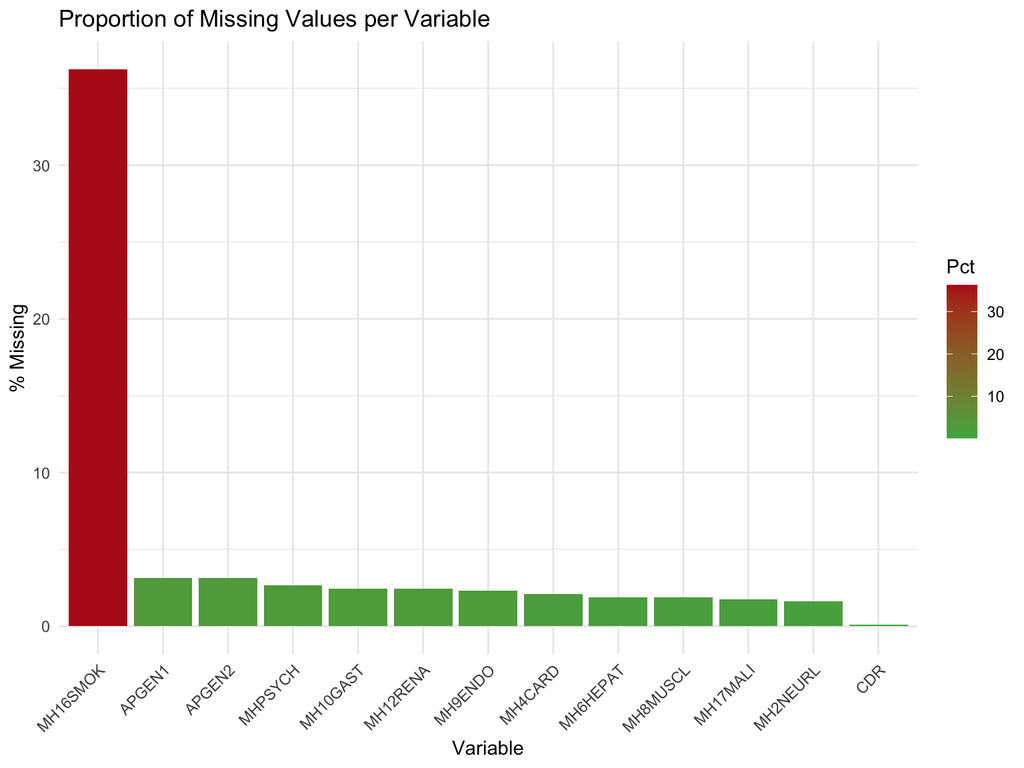

```r
ggplot(miss_df, aes(x = reorder(Variable, -Pct), y = Pct, fill = Pct)) +
  geom_col() +
  scale_fill_gradient(low = "#4CAF50", high = "#B71C1C") +
  labs(title = "Proportion of Missing Values per Variable",
       x = "Variable", y = "% Missing") +
  theme_minimal() +
  theme(axis.text.x = element_text(angle = 45, hjust = 1))
```